# Ajuste de um modelo em uma série temporal com tendência e/ou sazonalidade

Guilherme dos Santos

30/03/2019

# Importando a série temporal utilizando o pacote BETS

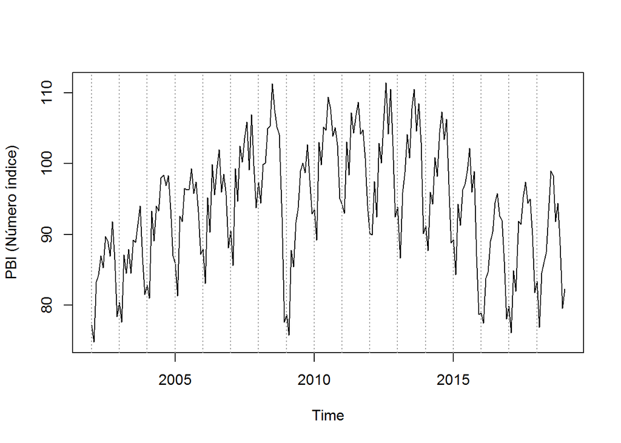

```r
library(BETS)

data <- BETSget(21864)

#gráfico da série
plot(data, ylab = "PBI (Número índice)", main = "")
abline(v = seq(2002,2018,1), col = "gray60", lty = 3)
```

# Ajuste do modelo e previsão

Como a série apresenta tendência e sazonalidade o modelo escolhido foi a suavização exponencial de Holt-Winters.

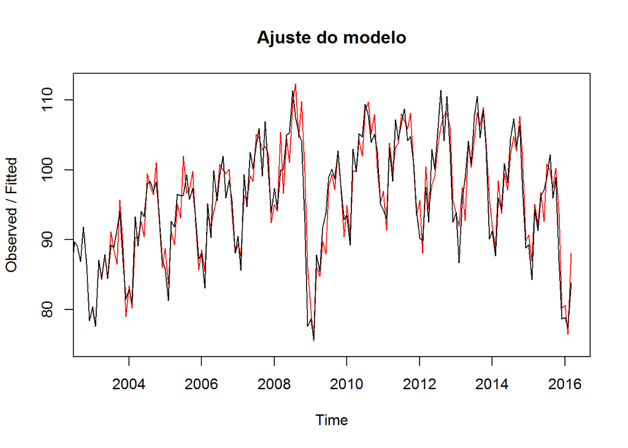

```r
library(forecast)

#deixando 2 anos para previsão
data_sub <- window(data, start = c(2002, 1), end = c(2016,3))

#Ajuste
modelo <- HoltWinters(data_sub)
plot(modelo, main = "Ajuste do modelo")
```

```r
summary(modelo)
```

```
##              Length Class  Mode
## fitted       636    mts    numeric
## x            171    ts     numeric
## alpha          1    -none- numeric
## beta           1    -none- numeric
## gamma          1    -none- numeric
## coefficients  14    -none- numeric
## seasonal       1    -none- character
## SSE            1    -none- numeric
## call           2    -none- call
```

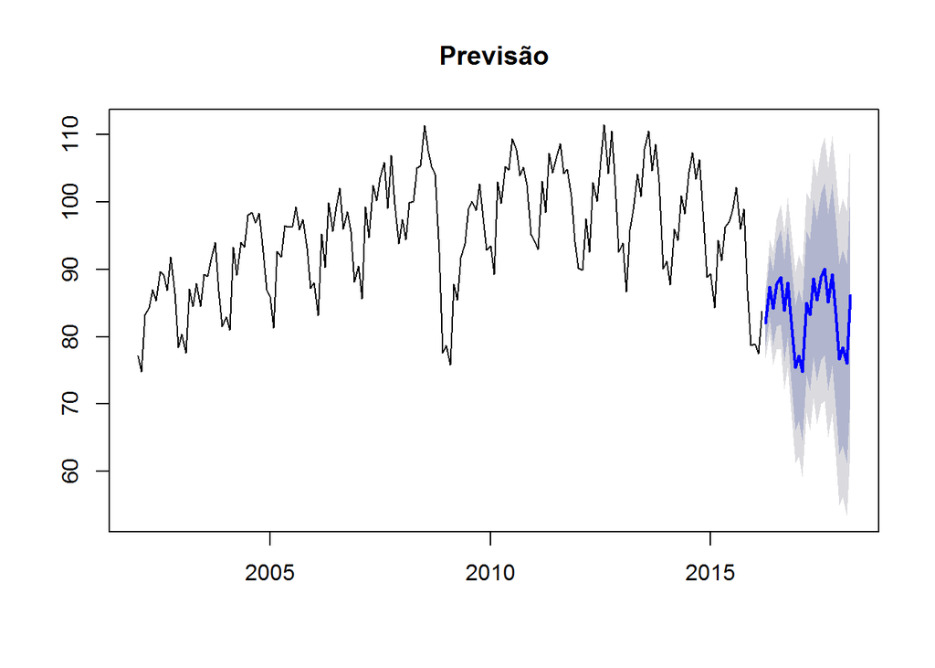

```r
#previsão
prev <- forecast(modelo)
plot(prev, main = "Previsão")
```

Vemos que a previsão tem período parecido com o da série, mas as previsões pontuais variam menos do que as observações até o ponto em que se inicia a previsão.

# Comparação da previsão pontual com os valores reais

No gráfico abaixo comparamos os valores reais (em preto) e os preditos (em vermelho).

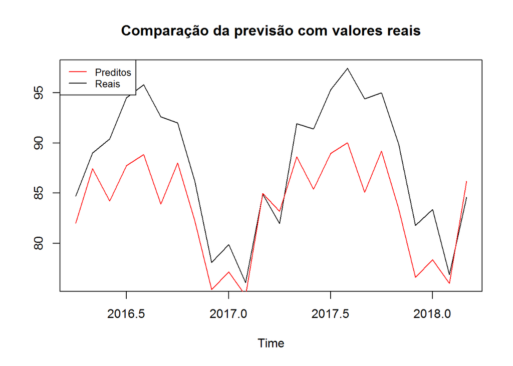

```r
prev <- as.data.frame(prev)
preditos <- ts(prev$`Point Forecast`, start = c(2016,4), end = c(2018,3), frequency = 12)
reais <- window(data, start = c(2016, 4), end = c(2018, 3))
plot(reais, ylab = NULL, main = "Comparação da previsão com valores reais")
lines(preditos, col = 2)
legend("topleft", legend=c("Preditos", "Reais"),
       col=c("red", "black"), lty=1, cex=0.8)
```

Vemos que na maioria dos pontos, a previsão pontual foi inferior ao valor real no momento, isto é, a previsão pontual do modelo subestima a Produção de Bens intermediários. No entanto, segue razoalvente bem o comportamento da série.

# Checando se os intervalos de confiança contêm o valor real

```r
lower <- prev$`Lo 80`
upper <- prev$`Hi 80`

cat("Quantidade de valores reais que estavam contidos no intervalo de 80%:",sum(lower <= reais & reais <= upper))
```

```
## Quantidade de valores reais que estavam contidos no intervalo de 80%: 21
```

```r
cat("Quantidade de valores reais que estavam contidos no intervalo de 95%:",sum(prev$`Lo 95` <= reais & reais <= prev$`Hi 95`))
```

```
## Quantidade de valores reais que estavam contidos no intervalo de 95%: 24
```

Como, na maioria dos casos, apenas as estimativas pontuais não são suficientes para tirar conclusões sobre um modelo, verificamos também se o valor real está contido dentro dos intervalos de confiança de 80% e 95%.

Vimos acima que 21 dos 24 valores reais estavam realmente contidos no intervalo de confiança de 80%. Mais ainda, todos os 24 valores reais estavam contidos no intervalo de 95% de confiança.